# Demo: Logistic diffusion model

# Setup

We begin by starting with a clean global environment and loading some packages.

```r
rm(list = ls())
# devtools::install_github("jeremyhengjm/UnbiasedScore")
library(UnbiasedScore)
```

```r
library(ggplot2)
library(ggthemes)
library(tictoc)
```

# Red kangaroo dataset and model

We consider an application from population ecology to model the dynamics of a population of red kangaroos (Macropus rufus) in New South Wales, Australia. Below we load the dataset from (Caughley, Shepherd, and Short 1987), which are double transect counts on $P=41$ occasions at irregular times $(t_p)$ between 1973 to 1984.

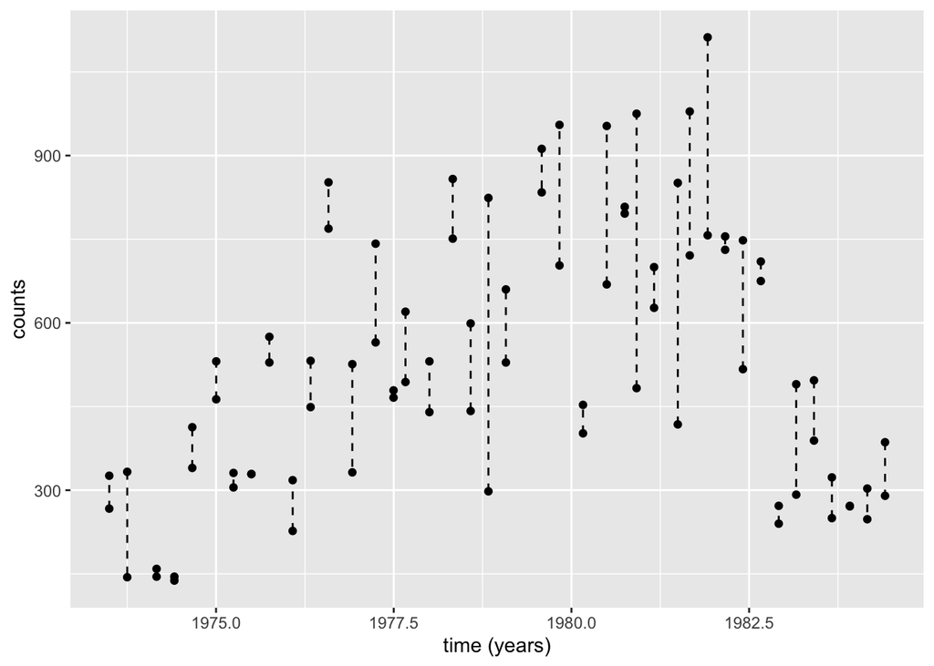

```r
load("../inst/logistic_diffusion/kangaroo.RData")
nobservations <- length(kangaroo$time)
observations <- matrix(0, nrow = nobservations, ncol = 2)
observations[, 1] <- kangaroo$count1
observations[, 2] <- kangaroo$count2
ggplot(kangaroo, aes(x = time)) +
  geom_segment(aes(x = time, y = count1, xend = time, yend = count2), linetype = "dashed", colour = "black") +
  geom_point(aes(y = count1)) +
  geom_point(aes(y = count2)) +
  xlab("time (years)") + ylab("counts")
```

The latent population size $Z=(Z_t)$ is assumed to follow a logistic diffusion process with environmental variance (Dennis and Costantino 1988), (Knape and De Valpine 2012) defined by
$$dZ_{t}=(\theta_{3}^{2}/2+\theta_{1}-\theta_{2}Z_{t})Z_{t}dt+\theta_{3}Z_{t}dW_{t},
\quad
Z_{t_1}\sim{LN}(5,10^2),$$
where ${LN}$ denotes the log-Normal distribution. As the parameter $\theta_{3}>0$ appears in the diffusion coefficient, we apply the Lamperti transformation $X_t = \log(Z_t)/\theta_3$ to obtain the process $X=(X_t)$ satisfying
$$dX_t = \{\theta_1/\theta_3-(\theta_2/\theta_3)\exp(\theta_3X_t)\}dt +
dW_t,$$
with normal initial distribution $X_{t_1}\sim{N}(5/\theta_3,10^2/\theta_3^{2})$. The observations $(Y_{t_p})_{p=1}^P$ are modelled as conditionally independent given $X$ and negative Binomial distributed, i.e. the conditional density at time $t\in\{t_1,\ldots,t_P\}$ is
$$g_{\theta}(y_t|x_t)={NB}(y_t^{1};\theta_{4},\exp(\theta_3x_t)){NB}(y_t^{2};\theta_{4},\exp(\theta_3x_t)).$$
Here we use the parameterization of the negative Binomial distribution that is common in ecology,
$${NB}(y;r,\mu)=\frac{\Gamma(y+r)}{\Gamma(r)y!}(\frac{r}{r+\mu})^{r}(\frac{\mu}{r+\mu})^{y},
\quad y\in\mathbb{N}_{0},$$
where $r>0$ is the dispersion parameter and $\mu>0$ is the mean parameter. The unknown parameters to be inferred are $\theta=(\theta_1,\theta_2,\theta_3,\theta_4)\in\mathbb{R}\times(0,\infty)^3$.

We construct objects that describe this hidden Markov model using the function `hmm_logistic_diffusion_full`. When defining the time-discretization, some care is required to deal with irregular observation times $(t_p)_{p=1}^P$; see the implementation and article for more details.

```r
model <- hmm_logistic_diffusion_full(kangaroo$time)
```

# Unbiased estimation

Below we specify all objects needed for our unbiased estimation procedure. We use the `independent_sum` estimator to obtain unbiased score approximations. Although unbiased estimators typically inflate the variance, this can be controlled using the time-averaging tuning parameters `k` and `m`.

```r
# settings
theta <- c(2.397, 4.429e-03, 0.840, 17.631) # fix a vector of parameters
discretization <- model$construct_successive_discretization(level = 5) # construct time-discretization objects
nparticles <- 2^8 # number of particles
resampling_threshold <- 0.5 # adaptive resampling threshold
coupled2_resampling <- coupled2_maximal_independent_residuals # Algorithm 3 of the article
coupled4_resampling <- coupled4_maximalchains_maximallevels_independent_residuals # Algorithm 5 of the article
initialization <- "dynamics" # choice to initialize CPF chains from time-discretized diffusion process
algorithm <- "CPF" # standard CPF algorithm

# distribution to truncate discretization level
minimum_level <- 4
maximum_level <- 20
level_distribution <- compute_level_distribution(model, minimum_level, maximum_level)
pmf.df <- data.frame(support = level_distribution$support, probability = level_distribution$mass_function)

# compute independent sum estimator of score function
score <- independent_sum(model, theta, observations, nparticles, resampling_threshold, coupled2_resampling, coupled4_resampling,
                         initialization, algorithm, k = 10, m = 50, level_distribution)
```

```
## running minimum level
## meeting time: 3
## minimum level completed
## random level: 4
```

```r
score
```

```
## $random_level
## [1] 4
##
## $unbiasedestimator
## [1]  -0.41926490 -23.02142938 -25.38218406   0.04798965
##
## $cost
## [1] 14217216
##
## $elapsedtime
## elapsed
##    3.07
```

# References

Caughley, Graeme, Neil Shepherd, and Jeff Short. 1987. *Kangaroos: Their Ecology and Management in the Sheep Rangelands of Australia*. Cambridge University Press.

Dennis, Brian, and Robert F Costantino. 1988. “Analysis of Steady-State Populations with the Gamma Abundance Model: Application to Tribolium.” *Ecology* 69 (4): 1200–1213.

Knape, Jonas, and Perry De Valpine. 2012. “Fitting Complex Population Models by Combining Particle Filters with Markov Chain Monte Carlo.” *Ecology* 93 (2): 256–63.